```python
# The usual preamble
import pandas as pd
# Open graphs in new cells in the page rather than in a separate window
%matplotlib inline
# Make the graphs a bit prettier, and bigger
pd.set_option('display.width', 5000)
pd.set_option('display.max_columns', 60)
```

We're going to use a new dataset here, to demonstrate how to deal with larger datasets. This is a subset of the of 311 service requests from [NYC Open Data](https://nycopendata.socrata.com/Social-Services/311-Service-Requests-from-2010-to-Present/erm2-nwe9).

```python
complaints = pd.read_csv('data/311-requests.csv')
```

# 1.1 What's even in it? (the summary)

```python
complaints
```

|  | Unique Key | Created Date | Closed Date | Agency | Agency Name | Complaint Type | Descriptor | Location Type | Incident Zip | Incident Address | Street Name | Cross Street 1 | Cross Street 2 | Intersection Street 1 | Intersection Street 2 | Address Type | City | Landmark | Facility Type | Status | Due Date | Resolution Action Updated Date | Community Board | Borough | X Coordinate (State Plane) | Y Coordinate (State Plane) | Park Facility Name | Park Borough | School Name | … |
| --- | --- | --- | --- | --- | --- | --- | --- | --- | --- | --- | --- | --- | --- | --- | --- | --- | --- | --- | --- | --- | --- | --- | --- | --- | --- | --- | --- | --- | --- | --- |
| 0 | 26589651 | 10/31/2013 02:08:41 AM | NaN | NYPD | New York City Police Department | Noise - Street/Sidewalk | Loud Talking | Street/Sidewalk | 11432 | 90-03 169 STREET | 169 STREET | 90 AVENUE | 91 AVENUE | NaN | NaN | ADDRESS | JAMAICA | NaN | Precinct | Assigned | 10/31/2013 10:08:41 AM | 10/31/2013 02:35:17 AM | 12 QUEENS | QUEENS | 1042027.0 | 197389.0 | Unspecified | QUEENS | Unspecified | … |
| 1 | 26593698 | 10/31/2013 02:01:04 AM | NaN | NYPD | New York City Police Department | Illegal Parking | Commercial Overnight Parking | Street/Sidewalk | 11378 | 58 AVENUE | 58 AVENUE | 58 PLACE | 59 STREET | NaN | NaN | BLOCKFACE | MASPETH | NaN | Precinct | Open | 10/31/2013 10:01:04 AM | NaN | 05 QUEENS | QUEENS | 1009349.0 | 201984.0 | Unspecified | QUEENS | Unspecified | … |
| 2 | 26594139 | 10/31/2013 02:00:24 AM | 10/31/2013 02:40:32 AM | NYPD | New York City Police Department | Noise - Commercial | Loud Music/Party | Club/Bar/Restaurant | 10032 | 4060 BROADWAY | BROADWAY | WEST 171 STREET | WEST 172 STREET | NaN | NaN | ADDRESS | NEW YORK | NaN | Precinct | Closed | 10/31/2013 10:00:24 AM | 10/31/2013 02:39:42 AM | 12 MANHATTAN | MANHATTAN | 1001088.0 | 246531.0 | Unspecified | MANHATTAN | Unspecified | … |
| 3 | 26595721 | 10/31/2013 01:56:23 AM | 10/31/2013 02:21:48 AM | NYPD | New York City Police Department | Noise - Vehicle | Car/Truck Horn | Street/Sidewalk | 10023 | WEST 72 STREET | WEST 72 STREET | COLUMBUS AVENUE | AMSTERDAM AVENUE | NaN | NaN | BLOCKFACE | NEW YORK | NaN | Precinct | Closed | 10/31/2013 09:56:23 AM | 10/31/2013 02:21:10 AM | 07 MANHATTAN | MANHATTAN | 989730.0 | 222727.0 | Unspecified | MANHATTAN | Unspecified | … |
| 4 | 26590930 | 10/31/2013 01:53:44 AM | NaN | DOHMH | Department of Health and Mental Hygiene | Rodent | Condition Attracting Rodents | Vacant Lot | 10027 | WEST 124 STREET | WEST 124 STREET | LENOX AVENUE | ADAM CLAYTON POWELL JR BOULEVARD | NaN | NaN | BLOCKFACE | NEW YORK | NaN | NaN | Pending | 11/30/2013 01:53:44 AM | 10/31/2013 01:59:54 AM | 10 MANHATTAN | MANHATTAN | 998815.0 | 233545.0 | Unspecified | MANHATTAN | Unspecified | … |
| 5 | 26592370 | 10/31/2013 01:46:52 AM | NaN | NYPD | New York City Police Department | Noise - Commercial | Banging/Pounding | Club/Bar/Restaurant | 11372 | 37 AVENUE | 37 AVENUE | 84 STREET | 85 STREET | NaN | NaN | BLOCKFACE | JACKSON HEIGHTS | NaN | Precinct | Open | 10/31/2013 09:46:52 AM | NaN | 03 QUEENS | QUEENS | 1016948.0 | 212540.0 | Unspecified | QUEENS | Unspecified | … |
| 6 | 26595682 | 10/31/2013 01:46:40 AM | NaN | NYPD | New York City Police Department | Blocked Driveway | No Access | Street/Sidewalk | 11419 | 107-50 109 STREET | 109 STREET | 107 AVENUE | 109 AVENUE | NaN | NaN | ADDRESS | SOUTH RICHMOND HILL | NaN | Precinct | Assigned | 10/31/2013 09:46:40 AM | 10/31/2013 01:59:51 AM | 10 QUEENS | QUEENS | 1030919.0 | 187622.0 | Unspecified | QUEENS | Unspecified | … |
| 7 | 26595195 | 10/31/2013 01:44:19 AM | 10/31/2013 01:58:49 AM | NYPD | New York City Police Department | Noise - Commercial | Loud Music/Party | Club/Bar/Restaurant | 11417 | 137-09 CROSSBAY BOULEVARD | CROSSBAY BOULEVARD | PITKIN AVENUE | VAN WICKLEN ROAD | NaN | NaN | ADDRESS | OZONE PARK | NaN | Precinct | Closed | 10/31/2013 09:44:19 AM | 10/31/2013 01:58:49 AM | 10 QUEENS | QUEENS | 1027776.0 | 184076.0 | Unspecified | QUEENS | Unspecified | … |
| 8 | 26590540 | 10/31/2013 01:44:14 AM | 10/31/2013 02:28:04 AM | NYPD | New York City Police Department | Noise - Commercial | Loud Talking | Club/Bar/Restaurant | 10011 | 258 WEST 15 STREET | WEST 15 STREET | 7 AVENUE | 8 AVENUE | NaN | NaN | ADDRESS | NEW YORK | NaN | Precinct | Closed | 10/31/2013 09:44:14 AM | 10/31/2013 02:00:56 AM | 04 MANHATTAN | MANHATTAN | 984031.0 | 208847.0 | Unspecified | MANHATTAN | Unspecified | … |
| 9 | 26594392 | 10/31/2013 01:34:41 AM | 10/31/2013 02:23:51 AM | NYPD | New York City Police Department | Noise - Commercial | Loud Music/Party | Club/Bar/Restaurant | 11225 | 835 NOSTRAND AVENUE | NOSTRAND AVENUE | UNION STREET | PRESIDENT STREET | NaN | NaN | ADDRESS | BROOKLYN | NaN | Precinct | Closed | 10/31/2013 09:34:41 AM | 10/31/2013 01:48:26 AM | 09 BROOKLYN | BROOKLYN | 997941.0 | 182725.0 | Unspecified | BROOKLYN | Unspecified | … |
| 10 | 26595176 | 10/31/2013 01:25:12 AM | NaN | NYPD | New York City Police Department | Noise - House of Worship | Loud Music/Party | House of Worship | 11218 | 3775 18 AVENUE | 18 AVENUE | EAST 9 STREET | EAST 8 STREET | NaN | NaN | ADDRESS | BROOKLYN | NaN | Precinct | Open | 10/31/2013 09:25:12 AM | NaN | 14 BROOKLYN | BROOKLYN | 992726.0 | 170399.0 | Unspecified | BROOKLYN | Unspecified | … |
| 11 | 26591982 | 10/31/2013 01:24:14 AM | 10/31/2013 01:54:39 AM | NYPD | New York City Police Department | Noise - Commercial | Loud Music/Party | Club/Bar/Restaurant | 10003 | 187 2 AVENUE | 2 AVENUE | EAST 11 STREET | EAST 12 STREET | NaN | NaN | ADDRESS | NEW YORK | NaN | Precinct | Closed | 10/31/2013 09:24:14 AM | 10/31/2013 01:54:39 AM | 03 MANHATTAN | MANHATTAN | 988110.0 | 205533.0 | Unspecified | MANHATTAN | Unspecified | … |
| 12 | 26594169 | 10/31/2013 01:20:57 AM | 10/31/2013 02:12:31 AM | NYPD | New York City Police Department | Illegal Parking | Double Parked Blocking Vehicle | Street/Sidewalk | 10029 | 65 EAST 99 STREET | EAST 99 STREET | MADISON AVENUE | PARK AVENUE | NaN | NaN | ADDRESS | NEW YORK | NaN | Precinct | Closed | 10/31/2013 09:20:57 AM | 10/31/2013 01:42:05 AM | 11 MANHATTAN | MANHATTAN | 997470.0 | 226725.0 | Unspecified | MANHATTAN | Unspecified | … |
| 13 | 26594391 | 10/31/2013 01:20:13 AM | NaN | NYPD | New York City Police Department | Noise - Vehicle | Engine Idling | Street/Sidewalk | 10466 | NaN | NaN | NaN | NaN | STRANG AVENUE | AMUNDSON AVENUE | INTERSECTION | BRONX | NaN | Precinct | Open | 10/31/2013 09:20:13 AM | NaN | 12 BRONX | BRONX | 1029467.0 | 264124.0 | Unspecified | BRONX | Unspecified | … |
| 14 | 26590917 | 10/31/2013 01:19:54 AM | NaN | DOHMH | Department of Health and Mental Hygiene | Rodent | Rat Sighting | 1-2 Family Mixed Use Building | 11219 | 63 STREET | 63 STREET | 13 AVENUE | 14 AVENUE | NaN | NaN | BLOCKFACE | BROOKLYN | NaN | NaN | Pending | 11/30/2013 01:19:54 AM | 10/31/2013 01:29:26 AM | 10 BROOKLYN | BROOKLYN | 984467.0 | 167519.0 | Unspecified | BROOKLYN | Unspecified | … |
| 15 | 26591458 | 10/31/2013 01:14:02 AM | 10/31/2013 01:30:34 AM | NYPD | New York City Police Department | Noise - House of Worship | Loud Music/Party | House of Worship | 10025 | NaN | NaN | NaN | NaN | WEST 99 STREET | BROADWAY | INTERSECTION | NEW YORK | NaN | Precinct | Closed | 10/31/2013 09:14:02 AM | 10/31/2013 01:30:34 AM | 07 MANHATTAN | MANHATTAN | 992454.0 | 229500.0 | Unspecified | MANHATTAN | Unspecified | … |
| 16 | 26594086 | 10/31/2013 12:54:03 AM | 10/31/2013 02:16:39 AM | NYPD | New York City Police Department | Noise - Street/Sidewalk | Loud Music/Party | Street/Sidewalk | 10310 | 173 CAMPBELL AVENUE | CAMPBELL AVENUE | HENDERSON AVENUE | WINEGAR LANE | NaN | NaN | ADDRESS | STATEN ISLAND | NaN | Precinct | Closed | 10/31/2013 08:54:03 AM | 10/31/2013 02:07:14 AM | 01 STATEN ISLAND | STATEN ISLAND | 952013.0 | 171076.0 | Unspecified | STATEN ISLAND | Unspecified | … |
| 17 | 26595117 | 10/31/2013 12:52:46 AM | NaN | NYPD | New York City Police Department | Illegal Parking | Posted Parking Sign Violation | Street/Sidewalk | 11236 | NaN | NaN | NaN | NaN | ROCKAWAY PARKWAY | SKIDMORE AVENUE | INTERSECTION | BROOKLYN | NaN | Precinct | Open | 10/31/2013 08:52:46 AM | NaN | 18 BROOKLYN | BROOKLYN | 1015289.0 | 169710.0 | Unspecified | BROOKLYN | Unspecified | … |
| 18 | 26590389 | 10/31/2013 12:51:00 AM | NaN | DOT | Department of Transportation | Street Light Condition | Street Light Out | NaN | NaN | 226 42 ST E | 42 ST E | CHURCH AVE | SNYDER AVE | NaN | NaN | ADDRESS | NaN | NaN | NaN | Open | NaN | NaN | Unspecified BROOKLYN | BROOKLYN | NaN | NaN | Unspecified | BROOKLYN | Unspecified | … |
| 19 | 26594210 | 10/31/2013 12:46:27 AM | NaN | NYPD | New York City Police Department | Noise - Commercial | Loud Music/Party | Club/Bar/Restaurant | 10033 | NaN | NaN | NaN | NaN | WEST 184 STREET | BROADWAY | INTERSECTION | NEW YORK | NaN | Precinct | Assigned | 10/31/2013 08:46:27 AM | 10/31/2013 01:32:41 AM | 12 MANHATTAN | MANHATTAN | 1002294.0 | 249712.0 | Unspecified | MANHATTAN | Unspecified | … |
| 20 | 26592932 | 10/31/2013 12:43:47 AM | 10/31/2013 12:56:20 AM | NYPD | New York City Police Department | Noise - House of Worship | Loud Music/Party | House of Worship | 11216 | 778 PARK PLACE | PARK PLACE | ROGERS AVENUE | NOSTRAND AVENUE | NaN | NaN | ADDRESS | BROOKLYN | NaN | Precinct | Closed | 10/31/2013 08:43:47 AM | 10/31/2013 12:56:20 AM | 08 BROOKLYN | BROOKLYN | 997608.0 | 184656.0 | Unspecified | BROOKLYN | Unspecified | … |
| 21 | 26594152 | 10/31/2013 12:41:17 AM | 10/31/2013 01:04:37 AM | NYPD | New York City Police Department | Noise - Commercial | Banging/Pounding | Store/Commercial | 10016 | 155 E 34TH ST | E 34TH ST | NaN | NaN | NaN | NaN | LATLONG | NEW YORK | NaN | Precinct | Closed | 10/31/2013 08:41:17 AM | 10/31/2013 01:04:38 AM | 06 MANHATTAN | MANHATTAN | 990133.0 | 211136.0 | Unspecified | MANHATTAN | Unspecified | … |
| 22 | 26589678 | 10/31/2013 12:39:55 AM | NaN | NYPD | New York City Police Department | Noise - Vehicle | Car/Truck Music | Street/Sidewalk | 11419 | NaN | NaN | NaN | NaN | 112 STREET | ATLANTIC AVENUE | INTERSECTION | SOUTH RICHMOND HILL | NaN | Precinct | Open | 10/31/2013 08:39:55 AM | NaN | 09 QUEENS | QUEENS | 1030314.0 | 191578.0 | Unspecified | QUEENS | Unspecified | … |
| 23 | 26592304 | 10/31/2013 12:38:00 AM | NaN | NYPD | New York City Police Department | Noise - Commercial | Loud Music/Party | Club/Bar/Restaurant | 11216 | 371 TOMPKINS AVENUE | TOMPKINS AVENUE | MADISON STREET | PUTNAM AVENUE | NaN | NaN | ADDRESS | BROOKLYN | NaN | Precinct | Assigned | 10/31/2013 08:38:00 AM | 10/31/2013 01:16:53 AM | 03 BROOKLYN | BROOKLYN | 999720.0 | 188825.0 | Unspecified | BROOKLYN | Unspecified | … |
| 24 | 26591892 | 10/31/2013 12:37:16 AM | NaN | NYPD | New York City Police Department | Blocked Driveway | Partial Access | Street/Sidewalk | 10305 | 1496 BAY STREET | BAY STREET | LYMAN AVENUE | SCHOOL ROAD | NaN | NaN | ADDRESS | STATEN ISLAND | NaN | Precinct | Assigned | 10/31/2013 08:37:16 AM | 10/31/2013 12:52:10 AM | 01 STATEN ISLAND | STATEN ISLAND | 967283.0 | 160518.0 | Unspecified | STATEN ISLAND | Unspecified | … |
| 25 | 26591573 | 10/31/2013 12:35:18 AM | 10/31/2013 02:41:35 AM | NYPD | New York City Police Department | Noise - Street/Sidewalk | Loud Talking | Street/Sidewalk | 10312 | 24 PRINCETON LANE | PRINCETON LANE | HAMPTON GREEN | DEAD END | NaN | NaN | ADDRESS | STATEN ISLAND | NaN | Precinct | Closed | 10/31/2013 08:35:18 AM | 10/31/2013 01:45:17 AM | 03 STATEN ISLAND | STATEN ISLAND | 929577.0 | 140964.0 | Unspecified | STATEN ISLAND | Unspecified | … |
| 26 | 26590509 | 10/31/2013 12:33:00 AM | NaN | DOT | Department of Transportation | Street Light Condition | Street Light Out | NaN | NaN | 38 ST E | 38 ST E | CHURCH AVE | LINDEN BLVD | NaN | NaN | BLOCKFACE | NaN | NaN | NaN | Open | NaN | NaN | Unspecified BROOKLYN | BROOKLYN | NaN | NaN | Unspecified | BROOKLYN | Unspecified | … |
| 27 | 26591379 | 10/31/2013 12:32:44 AM | NaN | DOHMH | Department of Health and Mental Hygiene | Harboring Bees/Wasps | Bees/Wasps - Not a beekeper | 3+ Family Mixed Use Building | 10025 | 501 WEST 110 STREET | WEST 110 STREET | AMSTERDAM AVENUE | BROADWAY | NaN | NaN | ADDRESS | NEW YORK | NaN | NaN | Open | 11/30/2013 12:32:44 AM | NaN | 09 MANHATTAN | MANHATTAN | 994143.0 | 231888.0 | Unspecified | MANHATTAN | Unspecified | … |
| 28 | 26594085 | 10/31/2013 12:32:08 AM | NaN | NYPD | New York City Police Department | Noise - Street/Sidewalk | Loud Talking | Street/Sidewalk | 10026 | 121 WEST 116 STREET | WEST 116 STREET | LENOX AVENUE | 7 AVENUE | NaN | NaN | ADDRESS | NEW YORK | NaN | Precinct | Assigned | 10/31/2013 08:32:08 AM | 10/31/2013 02:00:57 AM | 10 MANHATTAN | MANHATTAN | 997947.0 | 231613.0 | Unspecified | MANHATTAN | Unspecified | … |
| 29 | 26589201 | 10/31/2013 12:32:00 AM | NaN | DOT | Department of Transportation | Street Light Condition | Street Light Out | NaN | 10309 | 295 BAYVIEW AVENUE | BAYVIEW AVENUE | VAIL AVENUE | BAYVIEW LANE | NaN | NaN | ADDRESS | STATEN ISLAND | NaN | NaN | Open | NaN | NaN | 03 STATEN ISLAND | STATEN ISLAND | 927687.0 | 127837.0 | Unspecified | STATEN ISLAND | Unspecified | … |
| ... | ... | ... | ... | ... | ... | ... | ... | ... | ... | ... | ... | ... | ... | ... | ... | ... | ... | ... | ... | ... | ... | ... | ... | ... | ... | ... | ... | ... | ... | … |
| 49969 | 26521455 | 10/21/2013 12:00:00 AM | 10/24/2013 12:00:00 AM | HPD | Department of Housing Preservation and Develop... | NONCONST | VERMIN | RESIDENTIAL BUILDING | 10455 | 466 CONCORD AVENUE | CONCORD AVENUE | EAST 145 STREET | EAST 147 STREET | NaN | NaN | ADDRESS | BRONX | NaN | NaN | Closed | NaN | 10/24/2013 12:00:00 AM | 01 BRONX | BRONX | 1009465.0 | 234729.0 | Unspecified | BRONX | Unspecified | … |
| 49970 | 26521464 | 10/21/2013 12:00:00 AM | 10/22/2013 12:00:00 AM | HPD | Department of Housing Preservation and Develop... | HEATING | HEAT | RESIDENTIAL BUILDING | 10025 | 752 WEST END AVENUE | WEST END AVENUE | WEST 96 STREET | WEST 97 STREET | NaN | NaN | ADDRESS | NEW YORK | NaN | NaN | Closed | NaN | 10/22/2013 12:00:00 AM | 07 MANHATTAN | MANHATTAN | 991755.0 | 229161.0 | Unspecified | MANHATTAN | Unspecified | … |
| 49971 | 26521465 | 10/21/2013 12:00:00 AM | NaN | HPD | Department of Housing Preservation and Develop... | GENERAL CONSTRUCTION | DOORS | RESIDENTIAL BUILDING | 10459 | 1070 INTERVALE AVENUE | INTERVALE AVENUE | EAST 165 STREET | EAST 167 STREET | NaN | NaN | ADDRESS | BRONX | NaN | NaN | Open | NaN | 10/21/2013 12:00:00 AM | 02 BRONX | BRONX | 1012802.0 | 239912.0 | Unspecified | BRONX | Unspecified | … |
| 49972 | 26521468 | 10/21/2013 12:00:00 AM | NaN | HPD | Department of Housing Preservation and Develop... | HEATING | HEAT | RESIDENTIAL BUILDING | 11693 | 8800 SHORE FRONT PARKWAY | SHORE FRONT PARKWAY | BEACH 84 STREET | BEACH 90 STREET | NaN | NaN | ADDRESS | Far Rockaway | NaN | NaN | Open | NaN | 10/21/2013 12:00:00 AM | 14 QUEENS | QUEENS | 1036476.0 | 152356.0 | Unspecified | QUEENS | Unspecified | … |
| 49973 | 26524288 | 10/21/2013 12:00:00 AM | NaN | HPD | Department of Housing Preservation and Develop... | NONCONST | VERMIN | RESIDENTIAL BUILDING | 11237 | 238 WYCKOFF AVENUE | WYCKOFF AVENUE | MENAHAN STREET | GROVE STREET | NaN | NaN | ADDRESS | BROOKLYN | NaN | NaN | Open | NaN | 10/21/2013 12:00:00 AM | 04 BROOKLYN | BROOKLYN | 1008248.0 | 194621.0 | Unspecified | BROOKLYN | Unspecified | … |
| 49974 | 26524006 | 10/21/2013 12:00:00 AM | NaN | HPD | Department of Housing Preservation and Develop... | GENERAL CONSTRUCTION | CABINETS | RESIDENTIAL BUILDING | 11213 | 265 ROCHESTER AVENUE | ROCHESTER AVENUE | LINCOLN PLACE | EASTERN PARKWAY | NaN | NaN | ADDRESS | BROOKLYN | NaN | NaN | Open | NaN | 10/21/2013 12:00:00 AM | 08 BROOKLYN | BROOKLYN | 1004150.0 | 183176.0 | Unspecified | BROOKLYN | Unspecified | … |
| 49975 | 26524295 | 10/21/2013 12:00:00 AM | 10/25/2013 12:00:00 AM | HPD | Department of Housing Preservation and Develop... | NONCONST | VERMIN | RESIDENTIAL BUILDING | 10452 | 185 WEST 170 STREET | WEST 170 STREET | MERRIAM AVENUE | HIGH BRIDGE | NaN | NaN | ADDRESS | BRONX | NaN | NaN | Closed | NaN | 10/25/2013 12:00:00 AM | 04 BRONX | BRONX | 1004771.0 | 246025.0 | Unspecified | BRONX | Unspecified | … |
| 49976 | 26524319 | 10/21/2013 12:00:00 AM | NaN | HPD | Department of Housing Preservation and Develop... | HEATING | HEAT | RESIDENTIAL BUILDING | 11692 | 69-14 HESSLER AVENUE | HESSLER AVENUE | BEACH 69 STREET | BEACH 72 STREET | NaN | NaN | ADDRESS | Arverne | NaN | NaN | Open | NaN | 10/21/2013 12:00:00 AM | 14 QUEENS | QUEENS | 1040089.0 | 155789.0 | Unspecified | QUEENS | Unspecified | … |
| 49977 | 26524019 | 10/21/2013 12:00:00 AM | 10/24/2013 12:00:00 AM | HPD | Department of Housing Preservation and Develop... | NONCONST | VERMIN | RESIDENTIAL BUILDING | 10455 | 466 CONCORD AVENUE | CONCORD AVENUE | EAST 145 STREET | EAST 147 STREET | NaN | NaN | ADDRESS | BRONX | NaN | NaN | Closed | NaN | 10/24/2013 12:00:00 AM | 01 BRONX | BRONX | 1009465.0 | 234729.0 | Unspecified | BRONX | Unspecified | … |
| 49978 | 26524049 | 10/21/2013 12:00:00 AM | 10/23/2013 12:00:00 AM | HPD | Department of Housing Preservation and Develop... | APPLIANCE | ELECTRIC/GAS-RANGE | RESIDENTIAL BUILDING | 11229 | 2000 KINGS HIGHWAY | KINGS HIGHWAY | OCEAN AVENUE | AVENUE P | NaN | NaN | ADDRESS | BROOKLYN | NaN | NaN | Closed | NaN | 10/23/2013 12:00:00 AM | 15 BROOKLYN | BROOKLYN | 997169.0 | 161763.0 | Unspecified | BROOKLYN | Unspecified | … |
| 49979 | 26524043 | 10/21/2013 12:00:00 AM | NaN | HPD | Department of Housing Preservation and Develop... | PAINT - PLASTER | CEILING | RESIDENTIAL BUILDING | 10027 | 1350 AMSTERDAM AVENUE | AMSTERDAM AVENUE | WEST 125 STREET | WEST 126 STREET | NaN | NaN | ADDRESS | NEW YORK | NaN | NaN | Open | NaN | 10/21/2013 12:00:00 AM | 09 MANHATTAN | MANHATTAN | 996447.0 | 235785.0 | Unspecified | MANHATTAN | Unspecified | … |
| 49980 | 26524058 | 10/21/2013 12:00:00 AM | NaN | HPD | Department of Housing Preservation and Develop... | GENERAL CONSTRUCTION | DOORS | RESIDENTIAL BUILDING | 10460 | 1547 COMMONWEALTH AVENUE | COMMONWEALTH AVENUE | MANSION STREET | EAST TREMONT AVENUE | NaN | NaN | ADDRESS | BRONX | NaN | NaN | Open | NaN | 10/21/2013 12:00:00 AM | 09 BRONX | BRONX | 1020447.0 | 244888.0 | Unspecified | BRONX | Unspecified | … |
| 49981 | 26524061 | 10/21/2013 12:00:00 AM | NaN | HPD | Department of Housing Preservation and Develop... | PAINT - PLASTER | WALLS | RESIDENTIAL BUILDING | 11694 | 127 BEACH 119 STREET | BEACH 119 STREET | OCEAN PROMENADE | ROCKAWAY BEACH BOULEVARD | NaN | NaN | ADDRESS | Rockaway Park | NaN | NaN | Open | NaN | 10/21/2013 12:00:00 AM | 14 QUEENS | QUEENS | 1028968.0 | 149779.0 | Unspecified | QUEENS | Unspecified | … |
| 49982 | 26524081 | 10/21/2013 12:00:00 AM | NaN | HPD | Department of Housing Preservation and Develop... | GENERAL CONSTRUCTION | MOLD | RESIDENTIAL BUILDING | 10032 | 1090 ST NICHOLAS AVENUE | ST NICHOLAS AVENUE | WEST 164 STREET | MC KENNA SQUARE | NaN | NaN | ADDRESS | NEW YORK | NaN | NaN | Open | NaN | 10/21/2013 12:00:00 AM | 12 MANHATTAN | MANHATTAN | 1000880.0 | 244627.0 | Unspecified | MANHATTAN | Unspecified | … |
| 49983 | 26524099 | 10/21/2013 12:00:00 AM | NaN | HPD | Department of Housing Preservation and Develop... | PAINT - PLASTER | WALLS | RESIDENTIAL BUILDING | 10039 | 290 WEST 147 STREET | WEST 147 STREET | 7 AVENUE | 8 AVENUE | NaN | NaN | ADDRESS | NEW YORK | NaN | NaN | Open | NaN | 10/21/2013 12:00:00 AM | 10 MANHATTAN | MANHATTAN | 1000742.0 | 239447.0 | Unspecified | MANHATTAN | Unspecified | … |
| 49984 | 26524119 | 10/21/2013 12:00:00 AM | 10/24/2013 12:00:00 AM | HPD | Department of Housing Preservation and Develop... | PAINT - PLASTER | WALLS | RESIDENTIAL BUILDING | 11221 | 213 LEWIS AVENUE | LEWIS AVENUE | LEXINGTON AVENUE | QUINCY STREET | NaN | NaN | ADDRESS | BROOKLYN | NaN | NaN | Closed | NaN | 10/24/2013 12:00:00 AM | 03 BROOKLYN | BROOKLYN | 1001927.0 | 190341.0 | Unspecified | BROOKLYN | Unspecified | … |
| 49985 | 26524124 | 10/21/2013 12:00:00 AM | 10/22/2013 12:00:00 AM | HPD | Department of Housing Preservation and Develop... | HEATING | HEAT | RESIDENTIAL BUILDING | 11233 | 1526 EASTERN PARKWAY EXTENSION | EASTERN PARKWAY EXTENSION | ST JOHNS PLACE | SARATOGA AVENUE | NaN | NaN | ADDRESS | BROOKLYN | NaN | NaN | Closed | NaN | 10/22/2013 12:00:00 AM | 16 BROOKLYN | BROOKLYN | 1007078.0 | 183531.0 | Unspecified | BROOKLYN | Unspecified | … |
| 49986 | 26524263 | 10/21/2013 12:00:00 AM | 10/22/2013 12:00:00 AM | HPD | Department of Housing Preservation and Develop... | HEATING | HEAT | RESIDENTIAL BUILDING | 10460 | 961 EAST 173 STREET | EAST 173 STREET | VYSE AVENUE | BRYANT AVENUE | NaN | NaN | ADDRESS | BRONX | NaN | NaN | Closed | NaN | 10/22/2013 12:00:00 AM | 03 BRONX | BRONX | 1015614.0 | 243511.0 | Unspecified | BRONX | Unspecified | … |
| 49987 | 26524289 | 10/21/2013 12:00:00 AM | 10/24/2013 12:00:00 AM | HPD | Department of Housing Preservation and Develop... | HEATING | HEAT | RESIDENTIAL BUILDING | 10022 | 1026 1 AVENUE | 1 AVENUE | EAST 56 STREET | EAST 57 STREET | NaN | NaN | ADDRESS | NEW YORK | NaN | NaN | Closed | NaN | 10/24/2013 12:00:00 AM | 06 MANHATTAN | MANHATTAN | 994410.0 | 215342.0 | Unspecified | MANHATTAN | Unspecified | … |
| 49988 | 26524297 | 10/21/2013 12:00:00 AM | NaN | HPD | Department of Housing Preservation and Develop... | GENERAL CONSTRUCTION | CABINETS | RESIDENTIAL BUILDING | 10467 | 2526 BRONX PARK EAST | BRONX PARK EAST | MACE AVENUE | ALLERTON AVENUE | NaN | NaN | ADDRESS | BRONX | NaN | NaN | Open | NaN | 10/21/2013 12:00:00 AM | 11 BRONX | BRONX | 1020100.0 | 254001.0 | Unspecified | BRONX | Unspecified | … |
| 49989 | 26524405 | 10/21/2013 12:00:00 AM | NaN | HPD | Department of Housing Preservation and Develop... | PLUMBING | BATHTUB | RESIDENTIAL BUILDING | 11230 | 1709 CONEY ISLAND AVENUE | CONEY ISLAND AVENUE | RODER AVENUE | AVENUE N | NaN | NaN | ADDRESS | BROOKLYN | NaN | NaN | Open | NaN | 10/21/2013 12:00:00 AM | 14 BROOKLYN | BROOKLYN | 994389.0 | 163660.0 | Unspecified | BROOKLYN | Unspecified | … |
| 49990 | 26524458 | 10/21/2013 12:00:00 AM | 10/23/2013 12:00:00 AM | HPD | Department of Housing Preservation and Develop... | HEATING | HEAT | RESIDENTIAL BUILDING | 11207 | 726 MILLER AVENUE | MILLER AVENUE | BEND | HEGEMAN AVENUE | NaN | NaN | ADDRESS | BROOKLYN | NaN | NaN | Closed | NaN | 10/23/2013 12:00:00 AM | 05 BROOKLYN | BROOKLYN | 1015238.0 | 180724.0 | Unspecified | BROOKLYN | Unspecified | … |
| 49991 | 26524457 | 10/21/2013 12:00:00 AM | 10/25/2013 12:00:00 AM | HPD | Department of Housing Preservation and Develop... | PAINT - PLASTER | CEILING | RESIDENTIAL BUILDING | 10457 | 1997 HUGHES AVENUE | HUGHES AVENUE | EAST 178 STREET | EAST 179 STREET | NaN | NaN | ADDRESS | BRONX | NaN | NaN | Closed | NaN | 10/25/2013 12:00:00 AM | 06 BRONX | BRONX | 1014243.0 | 247905.0 | Unspecified | BRONX | Unspecified | … |
| 49992 | 26524460 | 10/21/2013 12:00:00 AM | 10/23/2013 12:00:00 AM | HPD | Department of Housing Preservation and Develop... | HEATING | HEAT | RESIDENTIAL BUILDING | 10458 | 2340 VALENTINE AVENUE | VALENTINE AVENUE | EAST 183 STREET | EAST 184 STREET | NaN | NaN | ADDRESS | BRONX | NaN | NaN | Closed | NaN | 10/23/2013 12:00:00 AM | 05 BRONX | BRONX | 1012545.0 | 251844.0 | Unspecified | BRONX | Unspecified | … |
| 49993 | 26524467 | 10/21/2013 12:00:00 AM | 10/25/2013 12:00:00 AM | HPD | Department of Housing Preservation and Develop... | PLUMBING | RADIATOR | RESIDENTIAL BUILDING | 10028 | 310 EAST 83 STREET | EAST 83 STREET | 2 AVENUE | 1 AVENUE | NaN | NaN | ADDRESS | NEW YORK | NaN | NaN | Closed | NaN | 10/25/2013 12:00:00 AM | 08 MANHATTAN | MANHATTAN | 997365.0 | 221887.0 | Unspecified | MANHATTAN | Unspecified | … |
| 49994 | 26524469 | 10/21/2013 12:00:00 AM | NaN | HPD | Department of Housing Preservation and Develop... | PAINT - PLASTER | CEILING | RESIDENTIAL BUILDING | 11235 | 2940 OCEAN AVENUE | OCEAN AVENUE | AVENUE Y | AVENUE Z | NaN | NaN | ADDRESS | BROOKLYN | NaN | NaN | Open | NaN | 10/21/2013 12:00:00 AM | 15 BROOKLYN | BROOKLYN | 998260.0 | 154071.0 | Unspecified | BROOKLYN | Unspecified | … |
| 49995 | 26524470 | 10/21/2013 12:00:00 AM | NaN | HPD | Department of Housing Preservation and Develop... | ELECTRIC | ELECTRIC-SUPPLY | RESIDENTIAL BUILDING | 10458 | 2704 DECATUR AVENUE | DECATUR AVENUE | EAST 195 STREET | EAST 197 STREET | NaN | NaN | ADDRESS | BRONX | NaN | NaN | Open | NaN | 10/21/2013 12:00:00 AM | 07 BRONX | BRONX | 1015067.0 | 254449.0 | Unspecified | BRONX | Unspecified | … |
| 49996 | 26524479 | 10/21/2013 12:00:00 AM | NaN | HPD | Department of Housing Preservation and Develop... | PAINT - PLASTER | WALLS | RESIDENTIAL BUILDING | 11373 | 51-55 VAN KLEECK STREET | VAN KLEECK STREET | CODWISE PLACE | KNEELAND AVENUE | NaN | NaN | ADDRESS | Elmhurst | NaN | NaN | Open | NaN | 10/21/2013 12:00:00 AM | 04 QUEENS | QUEENS | 1016917.0 | 207448.0 | Unspecified | QUEENS | Unspecified | … |
| 49997 | 26523160 | 10/21/2013 12:00:00 AM | NaN | HPD | Department of Housing Preservation and Develop... | GENERAL CONSTRUCTION | CERAMIC-TILE | RESIDENTIAL BUILDING | 10468 | 2600 CRESTON AVENUE | CRESTON AVENUE | EAST 192 STREET | EAST 193 STREET | NaN | NaN | ADDRESS | BRONX | NaN | NaN | Open | NaN | 10/21/2013 12:00:00 AM | 07 BRONX | BRONX | 1012886.0 | 254495.0 | Unspecified | BRONX | Unspecified | … |
| 49998 | 26523190 | 10/21/2013 12:00:00 AM | 10/22/2013 12:00:00 AM | HPD | Department of Housing Preservation and Develop... | NONCONST | VERMIN | RESIDENTIAL BUILDING | 10458 | 3184 GRAND CONCOURSE | GRAND CONCOURSE | EAST 206 STREET | ST GEORGES CRESCENT | NaN | NaN | ADDRESS | BRONX | NaN | NaN | Closed | NaN | 10/22/2013 12:00:00 AM | 07 BRONX | BRONX | 1015863.0 | 258627.0 | Unspecified | BRONX | Unspecified | … |

49999 rows × 52 columns

# 1.2 Selecting columns and rows

To select a column, we index with the name of the column, like this:

```python
complaints['Complaint Type']
```

```
0         Noise - Street/Sidewalk
1                 Illegal Parking
2              Noise - Commercial
3                 Noise - Vehicle
4                          Rodent
5              Noise - Commercial
6                Blocked Driveway
7              Noise - Commercial
8              Noise - Commercial
9              Noise - Commercial
10       Noise - House of Worship
11             Noise - Commercial
12                Illegal Parking
13                Noise - Vehicle
14                         Rodent
```

[output cut: 47 more lines]

To get the first 5 rows of a dataframe, we can use a slice: `df[:5]`.

This is a great way to get a sense for what kind of information is in the dataframe -- take a minute to look at the contents and get a feel for this dataset.

```python
complaints[:5]
```

|  | Unique Key | Created Date | Closed Date | Agency | Agency Name | Complaint Type | Descriptor | Location Type | Incident Zip | Incident Address | Street Name | Cross Street 1 | Cross Street 2 | Intersection Street 1 | Intersection Street 2 | Address Type | City | Landmark | Facility Type | Status | Due Date | Resolution Action Updated Date | Community Board | Borough | X Coordinate (State Plane) | Y Coordinate (State Plane) | Park Facility Name | Park Borough | School Name | … |
| --- | --- | --- | --- | --- | --- | --- | --- | --- | --- | --- | --- | --- | --- | --- | --- | --- | --- | --- | --- | --- | --- | --- | --- | --- | --- | --- | --- | --- | --- | --- |
| 0 | 26589651 | 10/31/2013 02:08:41 AM | NaN | NYPD | New York City Police Department | Noise - Street/Sidewalk | Loud Talking | Street/Sidewalk | 11432 | 90-03 169 STREET | 169 STREET | 90 AVENUE | 91 AVENUE | NaN | NaN | ADDRESS | JAMAICA | NaN | Precinct | Assigned | 10/31/2013 10:08:41 AM | 10/31/2013 02:35:17 AM | 12 QUEENS | QUEENS | 1042027.0 | 197389.0 | Unspecified | QUEENS | Unspecified | … |
| 1 | 26593698 | 10/31/2013 02:01:04 AM | NaN | NYPD | New York City Police Department | Illegal Parking | Commercial Overnight Parking | Street/Sidewalk | 11378 | 58 AVENUE | 58 AVENUE | 58 PLACE | 59 STREET | NaN | NaN | BLOCKFACE | MASPETH | NaN | Precinct | Open | 10/31/2013 10:01:04 AM | NaN | 05 QUEENS | QUEENS | 1009349.0 | 201984.0 | Unspecified | QUEENS | Unspecified | … |
| 2 | 26594139 | 10/31/2013 02:00:24 AM | 10/31/2013 02:40:32 AM | NYPD | New York City Police Department | Noise - Commercial | Loud Music/Party | Club/Bar/Restaurant | 10032 | 4060 BROADWAY | BROADWAY | WEST 171 STREET | WEST 172 STREET | NaN | NaN | ADDRESS | NEW YORK | NaN | Precinct | Closed | 10/31/2013 10:00:24 AM | 10/31/2013 02:39:42 AM | 12 MANHATTAN | MANHATTAN | 1001088.0 | 246531.0 | Unspecified | MANHATTAN | Unspecified | … |
| 3 | 26595721 | 10/31/2013 01:56:23 AM | 10/31/2013 02:21:48 AM | NYPD | New York City Police Department | Noise - Vehicle | Car/Truck Horn | Street/Sidewalk | 10023 | WEST 72 STREET | WEST 72 STREET | COLUMBUS AVENUE | AMSTERDAM AVENUE | NaN | NaN | BLOCKFACE | NEW YORK | NaN | Precinct | Closed | 10/31/2013 09:56:23 AM | 10/31/2013 02:21:10 AM | 07 MANHATTAN | MANHATTAN | 989730.0 | 222727.0 | Unspecified | MANHATTAN | Unspecified | … |
| 4 | 26590930 | 10/31/2013 01:53:44 AM | NaN | DOHMH | Department of Health and Mental Hygiene | Rodent | Condition Attracting Rodents | Vacant Lot | 10027 | WEST 124 STREET | WEST 124 STREET | LENOX AVENUE | ADAM CLAYTON POWELL JR BOULEVARD | NaN | NaN | BLOCKFACE | NEW YORK | NaN | NaN | Pending | 11/30/2013 01:53:44 AM | 10/31/2013 01:59:54 AM | 10 MANHATTAN | MANHATTAN | 998815.0 | 233545.0 | Unspecified | MANHATTAN | Unspecified | … |

We can combine these to get the first 5 rows of a column:

```python
complaints['Complaint Type'][:5]
```

```
0    Noise - Street/Sidewalk
1            Illegal Parking
2         Noise - Commercial
3            Noise - Vehicle
4                     Rodent
Name: Complaint Type, dtype: object
```

and it doesn't matter which direction we do it in:

```python
complaints[:5]['Complaint Type']
```

```
0    Noise - Street/Sidewalk
1            Illegal Parking
2         Noise - Commercial
3            Noise - Vehicle
4                     Rodent
Name: Complaint Type, dtype: object
```

# 1.3 Selecting multiple columns

What if we just want to know the complaint type and the borough, but not the rest of the information? Pandas makes it really easy to select a subset of the columns: just index with list of columns you want.

```python
complaints[['Complaint Type', 'Borough']]
```

|  | Complaint Type | Borough |
| --- | --- | --- |
| 0 | Noise - Street/Sidewalk | QUEENS |
| 1 | Illegal Parking | QUEENS |
| 2 | Noise - Commercial | MANHATTAN |
| 3 | Noise - Vehicle | MANHATTAN |
| 4 | Rodent | MANHATTAN |
| 5 | Noise - Commercial | QUEENS |
| 6 | Blocked Driveway | QUEENS |
| 7 | Noise - Commercial | QUEENS |
| 8 | Noise - Commercial | MANHATTAN |
| 9 | Noise - Commercial | BROOKLYN |
| 10 | Noise - House of Worship | BROOKLYN |
| 11 | Noise - Commercial | MANHATTAN |
| 12 | Illegal Parking | MANHATTAN |
| 13 | Noise - Vehicle | BRONX |
| 14 | Rodent | BROOKLYN |
| 15 | Noise - House of Worship | MANHATTAN |
| 16 | Noise - Street/Sidewalk | STATEN ISLAND |
| 17 | Illegal Parking | BROOKLYN |
| 18 | Street Light Condition | BROOKLYN |
| 19 | Noise - Commercial | MANHATTAN |
| 20 | Noise - House of Worship | BROOKLYN |
| 21 | Noise - Commercial | MANHATTAN |
| 22 | Noise - Vehicle | QUEENS |
| 23 | Noise - Commercial | BROOKLYN |
| 24 | Blocked Driveway | STATEN ISLAND |
| 25 | Noise - Street/Sidewalk | STATEN ISLAND |
| 26 | Street Light Condition | BROOKLYN |
| 27 | Harboring Bees/Wasps | MANHATTAN |
| 28 | Noise - Street/Sidewalk | MANHATTAN |
| 29 | Street Light Condition | STATEN ISLAND |
| ... | ... | ... |
| 49969 | NONCONST | BRONX |
| 49970 | HEATING | MANHATTAN |
| 49971 | GENERAL CONSTRUCTION | BRONX |
| 49972 | HEATING | QUEENS |
| 49973 | NONCONST | BROOKLYN |
| 49974 | GENERAL CONSTRUCTION | BROOKLYN |
| 49975 | NONCONST | BRONX |
| 49976 | HEATING | QUEENS |
| 49977 | NONCONST | BRONX |
| 49978 | APPLIANCE | BROOKLYN |
| 49979 | PAINT - PLASTER | MANHATTAN |
| 49980 | GENERAL CONSTRUCTION | BRONX |
| 49981 | PAINT - PLASTER | QUEENS |
| 49982 | GENERAL CONSTRUCTION | MANHATTAN |
| 49983 | PAINT - PLASTER | MANHATTAN |
| 49984 | PAINT - PLASTER | BROOKLYN |
| 49985 | HEATING | BROOKLYN |
| 49986 | HEATING | BRONX |
| 49987 | HEATING | MANHATTAN |
| 49988 | GENERAL CONSTRUCTION | BRONX |
| 49989 | PLUMBING | BROOKLYN |
| 49990 | HEATING | BROOKLYN |
| 49991 | PAINT - PLASTER | BRONX |
| 49992 | HEATING | BRONX |
| 49993 | PLUMBING | MANHATTAN |
| 49994 | PAINT - PLASTER | BROOKLYN |
| 49995 | ELECTRIC | BRONX |
| 49996 | PAINT - PLASTER | QUEENS |
| 49997 | GENERAL CONSTRUCTION | BRONX |
| 49998 | NONCONST | BRONX |

49999 rows × 2 columns

That showed us a summary, and then we can look at the first 10 rows:

```python
complaints[['Complaint Type', 'Borough']][:10]
```

|  | Complaint Type | Borough |
| --- | --- | --- |
| 0 | Noise - Street/Sidewalk | QUEENS |
| 1 | Illegal Parking | QUEENS |
| 2 | Noise - Commercial | MANHATTAN |
| 3 | Noise - Vehicle | MANHATTAN |
| 4 | Rodent | MANHATTAN |
| 5 | Noise - Commercial | QUEENS |
| 6 | Blocked Driveway | QUEENS |
| 7 | Noise - Commercial | QUEENS |
| 8 | Noise - Commercial | MANHATTAN |
| 9 | Noise - Commercial | BROOKLYN |

# 1.4 What's the most common complaint type?

This is a really easy question to answer! There's a `.value_counts()` method that we can use:

```python
complaints['Complaint Type'].value_counts()
```

```
HEATING                              11512
Street Light Condition                2995
GENERAL CONSTRUCTION                  2947
PLUMBING                              2148
DOF Literature Request                2093
PAINT - PLASTER                       2031
Blocked Driveway                      1804
NONCONST                              1462
Traffic Signal Condition              1426
Illegal Parking                       1354
Street Condition                      1295
Noise                                 1120
Water System                           980
ELECTRIC                               966
Dirty Conditions                       950
Noise - Commercial                     923
Building/Use                           869
Broken Muni Meter                      819
General Construction/Plumbing          711
Sanitation Condition                   699
Sewer                                  604
Rodent                                 573
Consumer Complaint                     536
Noise - Street/Sidewalk                488
Taxi Complaint                         454
Missed Collection (All Materials)      384
Damaged Tree                           365
Root/Sewer/Sidewalk Condition          364
Derelict Vehicle                       334
Graffiti                               324
                                     ...
Fire Alarm - Modification                3
Complaint                                3
Illegal Animal Sold                      2
Bus Stop Shelter Placement               2
Unsanitary Animal Facility               2
Misc. Comments                           2
Public Toilet                            2
Beach/Pool/Sauna Complaint               2
Transportation Provider Complaint        2
Compliment                               2
Snow                                     1
Fire Alarm - New System                  1
Opinion for the Mayor                    1
Public Assembly                          1
Ferry Complaint                          1
Municipal Parking Facility               1
Adopt-A-Basket                           1
Fire Alarm - Replacement                 1
Drinking Water                           1
DFTA Literature Request                  1
Illegal Animal Kept as Pet               1
Posting Advertisement                    1
Senior Center Complaint                  1
Stalled Sites                            1
Trans Fat                                1
Legal Services Provider Complaint        1
Invitation                               1
Tunnel Condition                         1
DHS Income Savings Requirement           1
Poison Ivy                               1
Name: Complaint Type, Length: 158, dtype: int64
```

If we just wanted the top 10 most common complaints, we can do this:

```python
complaint_counts = complaints['Complaint Type'].value_counts()
complaint_counts[:10]
```

```
HEATING                     11512
Street Light Condition       2995
GENERAL CONSTRUCTION         2947
PLUMBING                     2148
DOF Literature Request       2093
PAINT - PLASTER              2031
Blocked Driveway             1804
NONCONST                     1462
Traffic Signal Condition     1426
Illegal Parking              1354
Name: Complaint Type, dtype: int64
```

But it gets better! We can plot them!

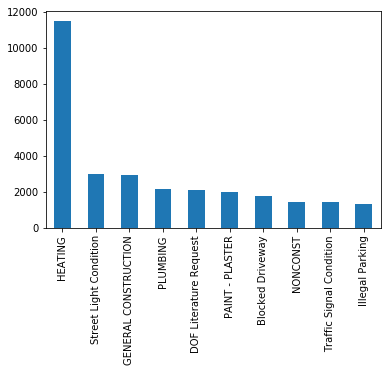

```python
complaint_counts[:10].plot(kind='bar')
```